# CSCI E-106:Assignment 6

### Due Date: November 3, 2020 at 7:20 pm EST

### Instructions

Students should submit their reports on Canvas. The report needs to clearly state what question is being solved, step-by-step walk-through solutions, and final answers clearly indicated. Please solve by hand where appropriate.

Please submit two files: (1) a R Markdown file (.Rmd extension) and (2) a PDF document, word, or html generated using knitr for the .Rmd file submitted in (1) where appropriate. Please, use RStudio Cloud for your solutions.

## Problem 1

Refer to Commercial properties data set. A commercial real estate company evaluates vacancy rates, square footage, rental rates, and operating expenses for commercial properties in a large metropolitan area in order to provide clients with quantitative information upon which to make rental decisions.The variables in the data set are the age ($X_1$), operating expenses and taxes ($X_2$), vacancy rates ($X_3$), total square footage ($X_4$),and rental rates (Y). (35 points, 5 points each)

a-) Obtain the scatter plot matrix and the correlation matrix. Interpret these and state your principal findings.

```r
# libraray read in
rm(list = ls())
setwd("~/OneDrive/courses/e106/e106_hes2020/HW/HW6") # change to local path

library(knitr)
library(onewaytests)
library(olsrr)
library(lmtest)
library(MASS)
library(ALSM)
# load data and check
prop <- read.csv('Commercial Properties Data Set.csv')
colnames(prop)
```

```
## [1] "Y"  "X1" "X2" "X3" "X4"
```

```r
head(prop)
```

```
##      Y X1    X2   X3     X4
## 1 13.5  1  5.02 0.14 123000
## 2 12.0 14  8.19 0.27 104079
## 3 10.5 16  3.00 0.00  39998
## 4 15.0  4 10.70 0.05  57112
## 5 14.0 11  8.97 0.07  60000
## 6 10.5 15  9.45 0.24 101385
```

```r
colnames(prop) <- c('rental','age','opex','vac_rate','area')
head(prop)
```

```
##   rental age  opex vac_rate   area
## 1   13.5   1  5.02     0.14 123000
## 2   12.0  14  8.19     0.27 104079
## 3   10.5  16  3.00     0.00  39998
## 4   15.0   4 10.70     0.05  57112
## 5   14.0  11  8.97     0.07  60000
## 6   10.5  15  9.45     0.24 101385
```

```r
str(prop)
```

```
## 'data.frame':    81 obs. of  5 variables:
##  $ rental  : num  13.5 12 10.5 15 14 10.5 14 16.5 17.5 16.5 ...
##  $ age     : int  1 14 16 4 11 15 2 1 1 8 ...
##  $ opex    : num  5.02 8.19 3 10.7 8.97 ...
##  $ vac_rate: num  0.14 0.27 0 0.05 0.07 0.24 0.19 0.6 0 0.03 ...
##  $ area    : int  123000 104079 39998 57112 60000 101385 31300 248172 215000 251015 ...
```

```r
summary(prop)
```

```
##      rental           age              opex           vac_rate
##  Min.   :10.50   Min.   : 0.000   Min.   : 3.000   Min.   :0.00000
##  1st Qu.:14.00   1st Qu.: 2.000   1st Qu.: 8.130   1st Qu.:0.00000
##  Median :15.00   Median : 4.000   Median :10.360   Median :0.03000
##  Mean   :15.14   Mean   : 7.864   Mean   : 9.688   Mean   :0.08099
##  3rd Qu.:16.50   3rd Qu.:15.000   3rd Qu.:11.620   3rd Qu.:0.09000
##  Max.   :19.25   Max.   :20.000   Max.   :14.620   Max.   :0.73000
##       area
##  Min.   : 27000
##  1st Qu.: 70000
##  Median :129614
##  Mean   :160633
##  3rd Qu.:236000
##  Max.   :484290
```

```
##          rental    age   opex vac_rate  area
## rental    1.000 -0.250  0.414    0.067 0.535
## age      -0.250  1.000  0.389   -0.253 0.289
## opex      0.414  0.389  1.000   -0.380 0.441
## vac_rate  0.067 -0.253 -0.380    1.000 0.081
## area      0.535  0.289  0.441    0.081 1.000
```

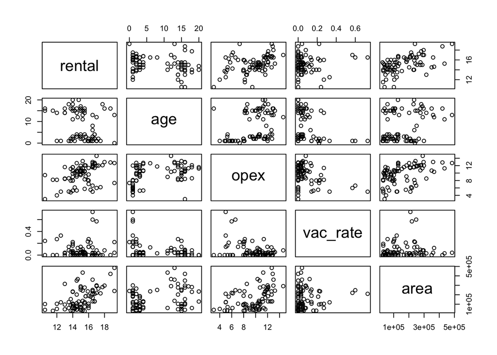

```r
# create plots & correlation matrices
corr_scat_func <- function(dfname) {
  print(round(cor(dfname),3))
  plot(dfname)
}

corr_scat_func(prop)
```

From the correlation plot we see that

1. Property age is negatively correlated with rental yield; we would expect older properties to be more run-down and be less attractive.
2. Vacancy rate has low correlation
3. Opex and Area have moderate correlation; 0.414 and 0.535 respectively ith rental
4. We also see that none of the variables have a high correlation with each other; this means we can hope to avoid multicollinearity.

b-) Fit regression model for four predictor variables to the data. State the estimated regression function.

```r
reg1b <- lm(rental~., data = prop)
summary(reg1b)
```

```
##
## Call:
## lm(formula = rental ~ ., data = prop)
##
## Residuals:
##     Min      1Q  Median      3Q     Max
## -3.1872 -0.5911 -0.0910  0.5579  2.9441
##
## Coefficients:
##               Estimate Std. Error t value Pr(>|t|)
## (Intercept)  1.220e+01  5.780e-01  21.110  < 2e-16 ***
## age         -1.420e-01  2.134e-02  -6.655 3.89e-09 ***
## opex         2.820e-01  6.317e-02   4.464 2.75e-05 ***
## vac_rate     6.193e-01  1.087e+00   0.570     0.57
## area         7.924e-06  1.385e-06   5.722 1.98e-07 ***
## ---
## Signif. codes:  0 '***' 0.001 '**' 0.01 '*' 0.05 '.' 0.1 ' ' 1
##
## Residual standard error: 1.137 on 76 degrees of freedom
## Multiple R-squared:  0.5847, Adjusted R-squared:  0.5629
## F-statistic: 26.76 on 4 and 76 DF,  p-value: 7.272e-14
```

```r
ei_1b <- reg1b$residuals
```

The regression function is stated as

rental = 1.22e+01 - 1.42e-01 * age + 2.82e-01 * opex + 6.19e-01 * vac_rate + 7.924e-06 * area

c-) Obtain the residuals and prepare a box plot of the residuals. Does the distribution appear to be fairly symmetrical?

```r
ei_1b[1:10] # printing 1st 10 variables
```

```
##          1          2          3          4          5          6          7
## -1.0356724 -1.5138064 -0.5910534 -0.1335681  0.3132838 -3.1871852 -0.5383567
##          8          9         10
##  0.2363024  1.9892204  0.1058296
```

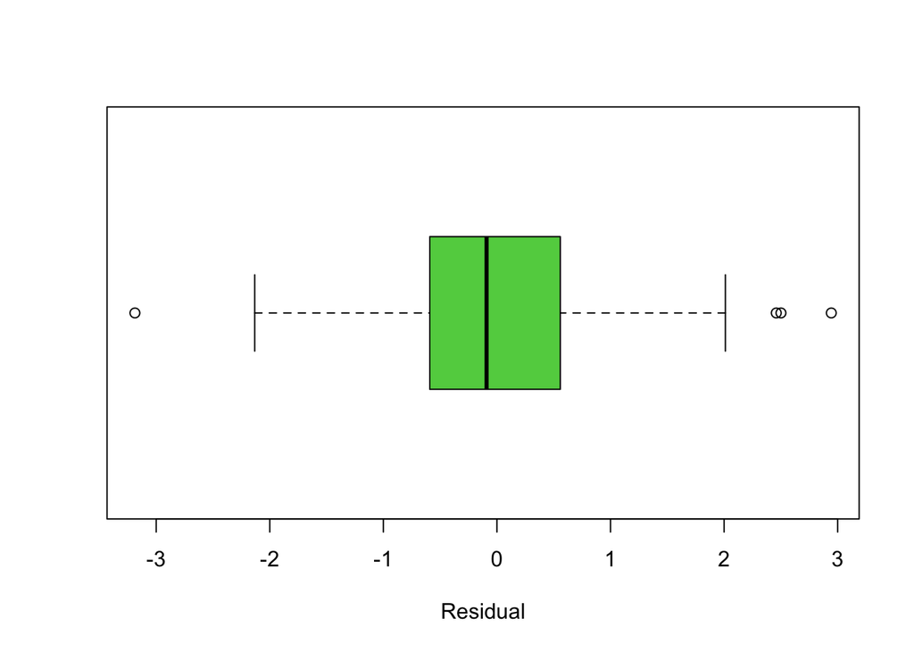

```r
# plots
newer.par = par(mfrow = c(1,1))
boxplot(ei_1b, horizontal = TRUE, staplewax = 0.5, col = 3, xlab = 'Residual')
```

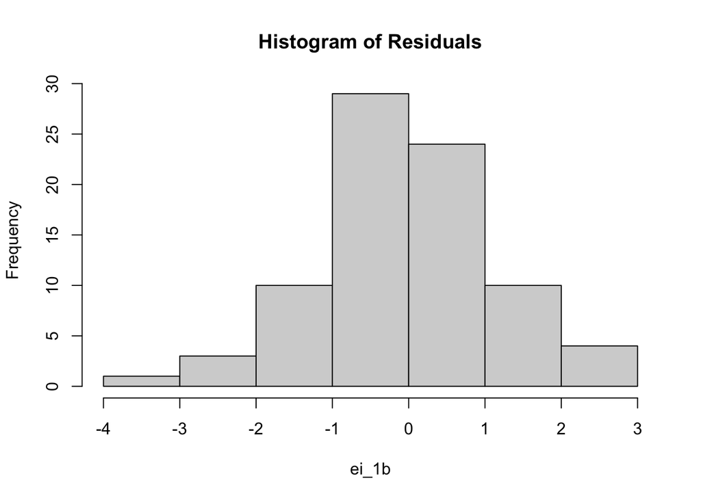

```r
hist(ei_1b, main = 'Histogram of Residuals')
```

```r
newer.par
```

```
## $mfrow
## [1] 1 1
```

From the plots above we see that the residuals appear to be slightly skewed to the right.

d-)Conduct the Breusch-Pagan test for constancy of the elTor varhmce, assuming log $\sigma_{i}^{2}$=$\gamma_0$+$\gamma_1X_1$+$\gamma_2X_2$+$\gamma_3X_3$+$\gamma_4X_4$ use $\alpha$ = .01. State the alternatives, decision rule, and conclusion

```r
# BP Test
bptest(reg1b)
```

```
##
##  studentized Breusch-Pagan test
##
## data:  reg1b
## BP = 12.978, df = 4, p-value = 0.01139
```

```r
# Ho : Errors are normally distributed; no heteroskedasticicty
# Ha : Errors are not normally distributed

# Decision Rule: p-value > 0.05 ==> Accept Ho
```

The p-value from the BP Test = 0.01139 which is less than 0.05. Hence, we reject Ho and conclude that heteroskedasticity is present.

e-) Obtain QQ plot and error vs. fitted values, and comment on the graphs.

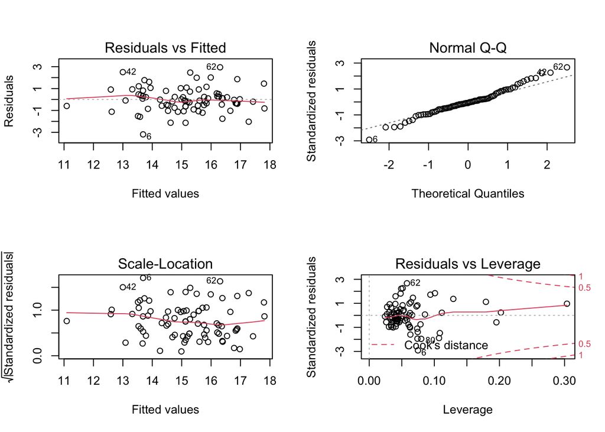

```r
newer.par = par(mfrow = c(2,2))
plot(reg1b)
```

```r
newer.par
```

```
## $mfrow
## [1] 1 1
```

The residuals vs fitted plot shows a fairly random pattern. The QQ plot line is close to 45 degrees up to + / - 1 SD.

This shows us that the following regression assumptions are satisfied

[output not shown]

f-) Estimate $\beta_0$, $\beta_1$, $\beta_2$, $\beta_3$ and $\beta_4$ jointly by the Bonferroni procedure, using a 95 percent family confidence coefficient. Interpret your results.

```r
confint(reg1b, level = 1-0.05/4)
```

```
##                   0.625 %      99.375 %
## (Intercept)  1.072186e+01  1.367931e+01
## age         -1.966396e-01 -8.742769e-02
## opex         1.203875e-01  4.436456e-01
## vac_rate    -2.161312e+00  3.399999e+00
## area         4.381297e-06  1.146731e-05
```

This means that when repeated samples are taken we would expect all the values to lie within the above range 95% of the time.

g-) $X_1$=5, $X_2$=8.25, $X_3$=0 and $X_4$=250000, calculate the predicted rental rate and 95% confidence interval

```r
newdata = data.frame(age = 5, opex = 8.25, vac_rate = 0, area = 250000)
predict.lm(reg1b, newdata, level = 1-0.05/4, interval = 'confidence')
```

```
##        fit      lwr      upr
## 1 15.79813 15.08664 16.50962
```

## Problem 2

Refer to the CDI data set. You have been asked to evaluate two alternative models for predicting the number of active ve physicians (Y) in a CDI. Proposed model I includes as predictor variables total population ($X_1$), land area ($X_2$), and total personal income ($X_3$). Proposed model II includes as predictor variables population density ($X_1$, total population divided by land area), percent of population greater than 64 years old ($X_2$), and total personal income ($X_3$).(40 points, 10 points each)

a-) Obtain the scatter plot matrix and the correlation matrix for each proposed model. Summarize the information provided.

```r
# load data and check
cdi <- read.csv('CDI Data.csv')
colnames(cdi)
```

```
##  [1] "Identification.number"             "County"
##  [3] "State"                             "Land.area"
##  [5] "Total.population"                  "Percent.of.population.aged.18.34"
##  [7] "Percent.of.population.65.or.older" "Number.of.active.physicians"
##  [9] "Number.of.hospital.beds"           "Total.serious.crimes"
## [11] "Percent.high.school.graduates"     "Percent.bachelor.s.degrees"
## [13] "Percent.below.poverty.level"       "Percent.unemployment"
## [15] "Per.capita.income"                 "Total.personal.income"
## [17] "Geographic.region"
```

```r
head(cdi)
```

```
##   Identification.number      County State Land.area Total.population
## 1                     1 Los_Angeles    CA      4060          8863164
## 2                     2        Cook    IL       946          5105067
## 3                     3      Harris    TX      1729          2818199
## 4                     4   San_Diego    CA      4205          2498016
## 5                     5      Orange    CA       790          2410556
## 6                     6       Kings    NY        71          2300664
##   Percent.of.population.aged.18.34 Percent.of.population.65.or.older
## 1                             32.1                               9.7
## 2                             29.2                              12.4
## 3                             31.3                               7.1
## 4                             33.5                              10.9
## 5                             32.6                               9.2
## 6                             28.3                              12.4
##   Number.of.active.physicians Number.of.hospital.beds Total.serious.crimes
```

[output cut: 27 more lines]

```r
# create df for proposed model 1
cols_cdi1 <- c('Number.of.active.physicians', 'Total.population', 'Land.area', 'Total.personal.income')

cdi_reg1 <- cdi[cols_cdi1]
dim(cdi_reg1)
```

```
## [1] 440   4
```

```r
colnames(cdi_reg1) <- c('Y', 'X1','X2','X3')
head(cdi_reg1)
```

```
##       Y      X1   X2     X3
## 1 23677 8863164 4060 184230
## 2 15153 5105067  946 110928
## 3  7553 2818199 1729  55003
## 4  5905 2498016 4205  48931
## 5  6062 2410556  790  58818
## 6  4861 2300664   71  38658
```

```r
# add new column
cdi$population.density <- cdi$Total.population/cdi$Land.area

# create df for proposed model 2
cols_cdi2 <- c('Number.of.active.physicians', 'population.density', 'Percent.of.population.65.or.older', 'Total.personal.income')

cdi_reg2 <- cdi[cols_cdi2]
dim(cdi_reg2)
```

```
## [1] 440   4
```

```r
colnames(cdi_reg2) <- c('Y', 'X1','X2','X3')
head(cdi_reg2)
```

```
##       Y         X1   X2     X3
## 1 23677  2183.0453  9.7 184230
## 2 15153  5396.4767 12.4 110928
## 3  7553  1629.9589  7.1  55003
## 4  5905   594.0585 10.9  48931
## 5  6062  3051.3367  9.2  58818
## 6  4861 32403.7183 12.4  38658
```

```
##        Y    X1    X2    X3
## Y  1.000 0.940 0.078 0.948
## X1 0.940 1.000 0.173 0.987
## X2 0.078 0.173 1.000 0.127
## X3 0.948 0.987 0.127 1.000
```

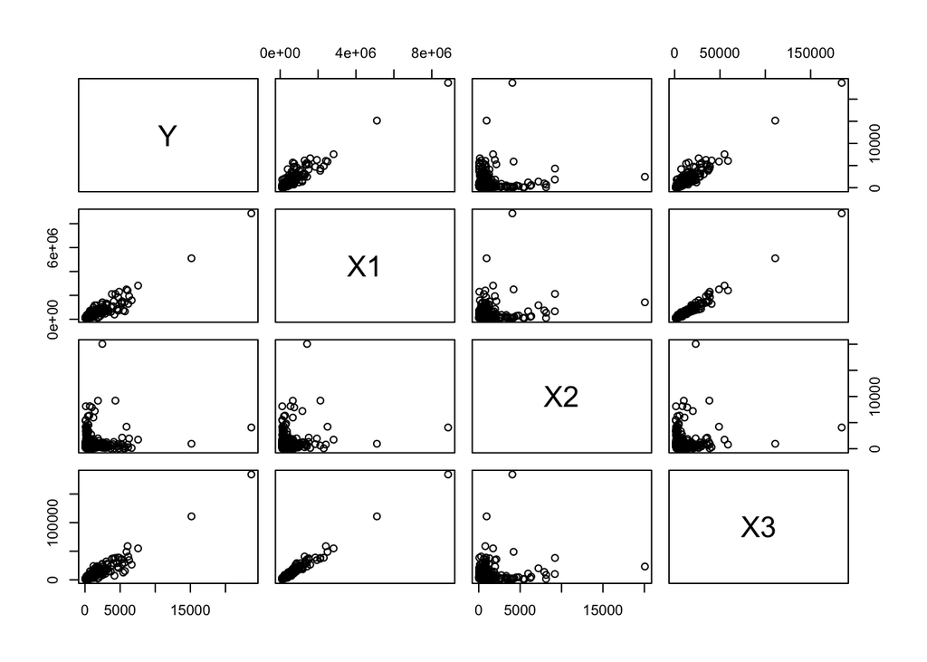

```r
# correlation values and scatter plots
corr_scat_func(cdi_reg1)
```

```r
corr_scat_func(cdi_reg2)
```

```
##         Y    X1     X2     X3
## Y   1.000 0.406 -0.003  0.948
## X1  0.406 1.000  0.029  0.316
## X2 -0.003 0.029  1.000 -0.023
## X3  0.948 0.316 -0.023  1.000
```

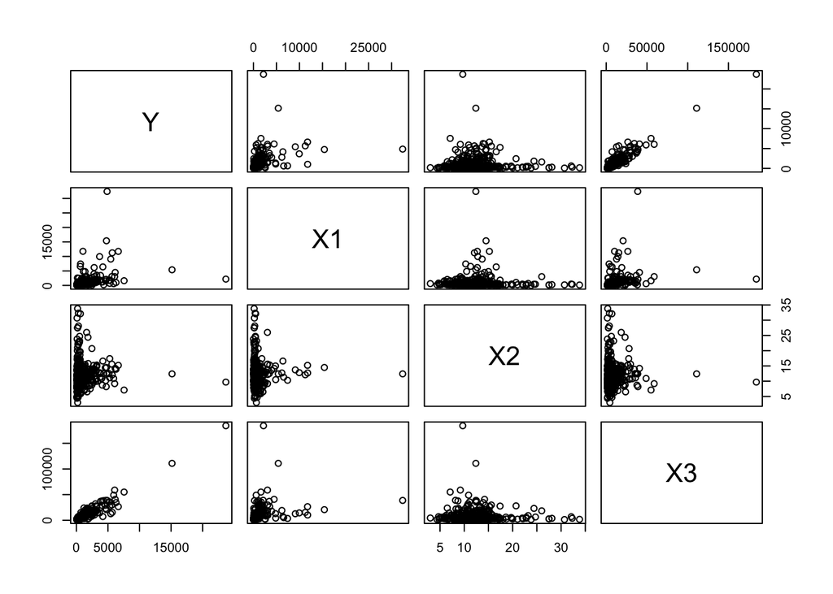

From the scatter plot and correlation matrix for proposed model 1 we see that 1. X1 and X3 have linear relations though outliers are present 2. Correlation for X1 & X3 with Y are similar 0.94 (X1) vs 0.948 (X2) 3. X1 and X3 have very high correlation with each other 0.987; which needs to be monitored for adverse effects on the regression models 4. X2 has low correlation with all other variables; we may need to transform X2 for regression.

From the scatter plot and correlation matrix for proposed model 2 we see that 1. X1 has some correlation with Y but we may need further tranformation 2. X2 has slight negative correlation with Y (-0.003); effectively close to zero 3. X3 has linear relationship with Y and correlation of 0.948 4. X1 and X3 have slight correlation 0.32 with each other.

b-) For each proposed model, fit the first-order regression model with three predictor variables.

```r
# proposed model 1
reg2b1 <- lm(Y~., data = cdi_reg1)
summary(reg2b1)
```

```
##
## Call:
## lm(formula = Y ~ ., data = cdi_reg1)
##
## Residuals:
##     Min      1Q  Median      3Q     Max
## -1855.6  -215.2   -74.6    79.0  3689.0
##
## Coefficients:
##               Estimate Std. Error t value Pr(>|t|)
## (Intercept) -1.332e+01  3.537e+01  -0.377 0.706719
## X1           8.366e-04  2.867e-04   2.918 0.003701 **
## X2          -6.552e-02  1.821e-02  -3.597 0.000358 ***
## X3           9.413e-02  1.330e-02   7.078 5.89e-12 ***
## ---
## Signif. codes:  0 '***' 0.001 '**' 0.01 '*' 0.05 '.' 0.1 ' ' 1
##
## Residual standard error: 560.4 on 436 degrees of freedom
## Multiple R-squared:  0.9026, Adjusted R-squared:  0.902
## F-statistic:  1347 on 3 and 436 DF,  p-value: < 2.2e-16
```

```r
ei_2b1 <- reg2b1$residuals

# proposed model 2
reg2b2 <- lm(Y~., data = cdi_reg2)
summary(reg2b2)
```

```
##
## Call:
## lm(formula = Y ~ ., data = cdi_reg2)
##
## Residuals:
##      Min       1Q   Median       3Q      Max
## -3055.75  -175.30   -38.05    72.88  3045.81
##
## Coefficients:
##               Estimate Std. Error t value Pr(>|t|)
## (Intercept) -1.706e+02  8.353e+01  -2.042   0.0418 *
## X1           9.616e-02  1.224e-02   7.857  3.1e-14 ***
## X2           6.340e+00  6.384e+00   0.993   0.3212
## X3           1.266e-01  2.084e-03  60.723  < 2e-16 ***
## ---
## Signif. codes:  0 '***' 0.001 '**' 0.01 '*' 0.05 '.' 0.1 ' ' 1
##
## Residual standard error: 533.5 on 436 degrees of freedom
## Multiple R-squared:  0.9117, Adjusted R-squared:  0.9111
## F-statistic:  1501 on 3 and 436 DF,  p-value: < 2.2e-16
```

```r
ei_2b2 <- reg2b2$residuals
```

c-) Calculate $R^2$ for each model. Is one model clearly preferable in terms of this measure?

```r
summary(reg2b1)$r.squared
```

```
## [1] 0.9026432
```

```r
summary(reg2b1)$adj.r.squared
```

```
## [1] 0.9019733
```

```r
summary(reg2b2)$r.squared
```

```
## [1] 0.9117491
```

```r
summary(reg2b2)$adj.r.squared
```

```
## [1] 0.9111419
```

Proposed model 2 has adjusted R2 that is higher than model 1 by 0.0091686. It would be difficult to choose betwene the 2

d-) For each model, obtain the residuals and plot them against $\hat{Y}$, each of the three predictor variables. Also prepare a normal probability plot for each of the two fitted models. Interpret your plots and state your findings. Is one model clearly preferable in terms of appropriateness?

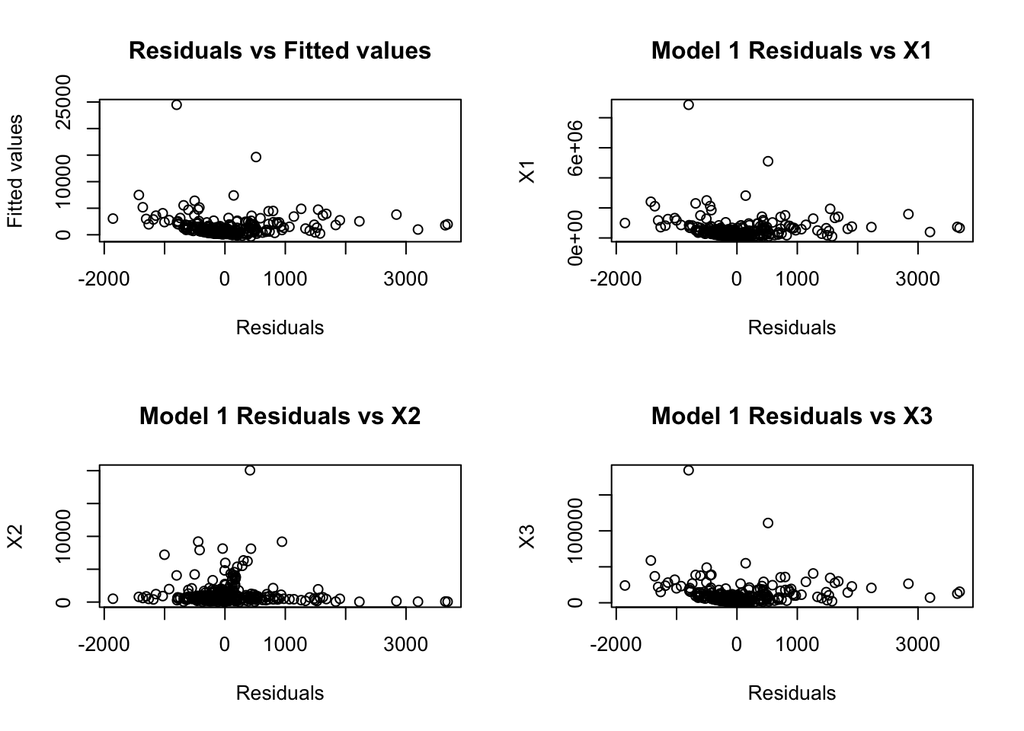

```r
old.par <- par(mfrow = c(2,2))
plot(ei_2b1,reg2b1$fitted.values, xlab = 'Residuals', ylab = 'Fitted values', main = 'Residuals vs Fitted values')
plot(ei_2b1,cdi_reg1$X1, xlab = 'Residuals', ylab = 'X1', main = 'Model 1 Residuals vs X1')
plot(ei_2b1,cdi_reg1$X2, xlab = 'Residuals', ylab = 'X2', main = 'Model 1 Residuals vs X2')
plot(ei_2b1,cdi_reg1$X3, xlab = 'Residuals', ylab = 'X3', main = 'Model 1 Residuals vs X3')
```

```r
old.par
```

```
## $mfrow
## [1] 1 1
```

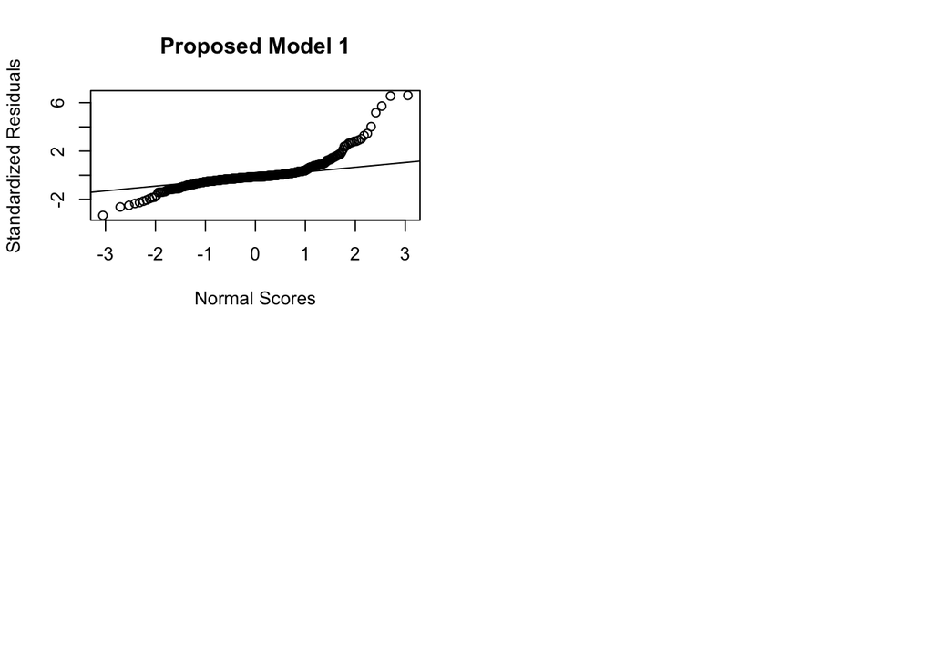

```r
reg2b1_stdres = rstandard(reg2b1)
qqnorm(reg2b1_stdres,ylab="Standardized Residuals",xlab="Normal Scores",main="Proposed Model 1")
qqline(reg2b1_stdres)

old.par <- par(mfrow = c(2,2))
```

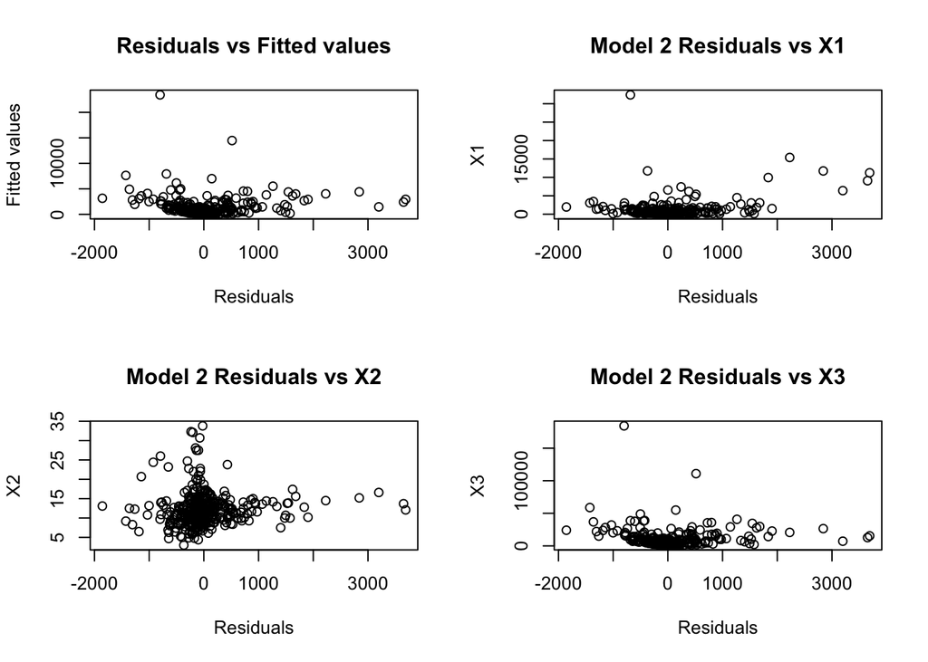

```r
plot(ei_2b1,reg2b2$fitted.values, xlab = 'Residuals', ylab = 'Fitted values', main = 'Residuals vs Fitted values')
plot(ei_2b1,cdi_reg2$X1, xlab = 'Residuals', ylab = 'X1', main = 'Model 2 Residuals vs X1')
plot(ei_2b1,cdi_reg2$X2, xlab = 'Residuals', ylab = 'X2', main = 'Model 2 Residuals vs X2')
plot(ei_2b1,cdi_reg2$X3, xlab = 'Residuals', ylab = 'X3', main = 'Model 2 Residuals vs X3')
```

```r
old.par
```

```
## $mfrow
## [1] 2 2
```

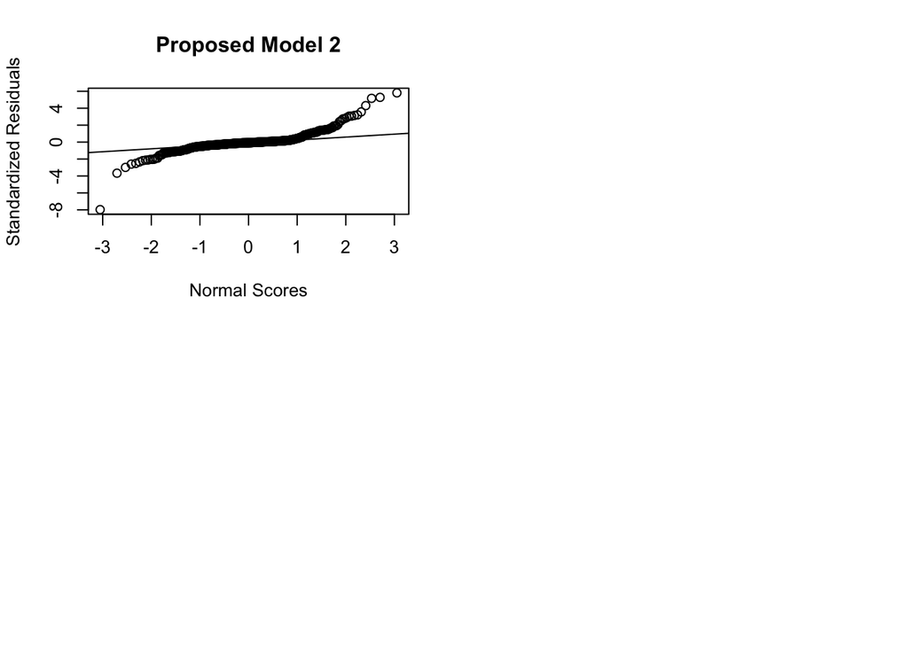

```r
reg2b2_stdres = rstandard(reg2b2)
qqnorm(reg2b2_stdres,ylab="Standardized Residuals",xlab="Normal Scores",main="Proposed Model 2")
qqline(reg2b2_stdres)
```

we see similar results for both plots. The residuals vs fitted values and residuals vs X1, X2, X3 plots all have patterns and outliers and hence do not meet any of the linear regression assumptions of linearity, normality, constant variance, independence or outliers.

## Problem 3

Refer to Grocery retailer data set.A large, national grocery retailer tracks productivity and costs of its facilities closely. Each data point for each variable represents one week of activity. The variables included are the number of cases shipped ($X_1$),the indirect costs of the total labor hours as a percentage ($X_2$), a qualitative predictor called holiday that is coded 1 if the week has a holiday and 0 otherwise ($X_3$), and the total labor hours (Y). (25 points, 5 points each)

a-) Fit regression model to the data for three predictor variables. State the estimated regression function. How are $b_1$, $b_2$ , and $b_3$ interpreted here? (5 points)

```r
veg <- read.csv('Grocery Retailer Data Set.csv')
dim(veg)
```

```
## [1] 52  4
```

```r
head(veg)
```

```
##      Y     X1   X2 X3
## 1 4264 305657 7.17  0
## 2 4496 328476 6.20  0
## 3 4317 317164 4.61  0
## 4 4292 366745 7.02  0
## 5 4945 265518 8.61  1
## 6 4325 301995 6.88  0
```

```r
reg3a <- lm(Y~., data = veg)
summary(reg3a)
```

```
##
## Call:
## lm(formula = Y ~ ., data = veg)
##
## Residuals:
##     Min      1Q  Median      3Q     Max
## -264.05 -110.73  -22.52   79.29  295.75
##
## Coefficients:
##               Estimate Std. Error t value Pr(>|t|)
## (Intercept)  4.150e+03  1.956e+02  21.220  < 2e-16 ***
## X1           7.871e-04  3.646e-04   2.159   0.0359 *
## X2          -1.317e+01  2.309e+01  -0.570   0.5712
## X3           6.236e+02  6.264e+01   9.954 2.94e-13 ***
## ---
## Signif. codes:  0 '***' 0.001 '**' 0.01 '*' 0.05 '.' 0.1 ' ' 1
##
## Residual standard error: 143.3 on 48 degrees of freedom
## Multiple R-squared:  0.6883, Adjusted R-squared:  0.6689
## F-statistic: 35.34 on 3 and 48 DF,  p-value: 3.316e-12
```

```r
ei_3a <- reg3a$res
```

The regression function is stated as below

Y = 4.15e+03 + 7.871e-04 * X1 - 1.317e+01 * X2 + 6.236e+02 * X3

total labor hours = 4.15e+03 + 7.871e-04 * (num of cases shipped) - 1.317e+01 * (total labor hrs as percent) + 6.236e+02 * (holiday in week or not)

The coefficients are interpreted as the unit change in total labor hours for unit change in the associated predictor variable holding all other predictor variables constant.

b-)Prepare a time plot of the residuals. Is there any indication of that the error terms are correlated?

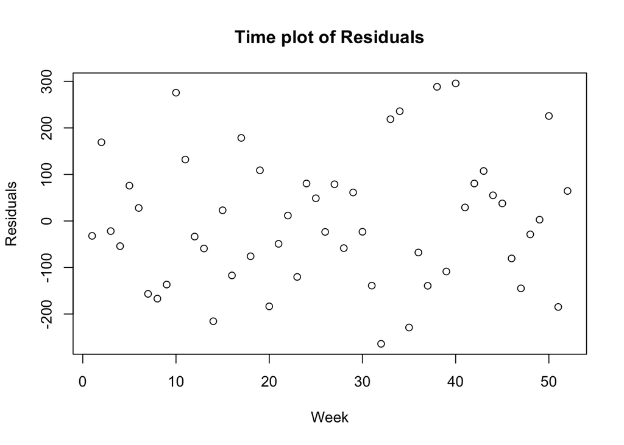

```r
plot(sequence(nrow(veg)), ei_3a, xlab = 'Week', ylab = 'Residuals', main = 'Time plot of Residuals')
```

From the plot above we see that the residuals are randomly distributed and hence uncorelated.

c-) Obtain the analysis of variance table that decomposes the regression sum of squares into extra sums of squares associated with $X_1$; with $X_3$ , given $X_1$; and with $X_2$ , given $X_1$, and $X_3$.

ANOVA tables are calculated as below

```r
# Anova with X1
f1 <- lm(Y~X1, data = veg)
a1 <- anova(f1)
a1
```

```
## Analysis of Variance Table
##
## Response: Y
##           Df  Sum Sq Mean Sq F value Pr(>F)
## X1         1  136366  136366  2.2534 0.1396
## Residuals 50 3025770   60515
```

```r
ssr_a1 <- a1$`Sum Sq`[1]
ssr_a1
```

```
## [1] 136366.2
```

```r
# Anova with X3 given X1
f13 <- lm(Y~X1+X3, data = veg)
a13 <- anova(f13)
a13
```

```
## Analysis of Variance Table
##
## Response: Y
##           Df  Sum Sq Mean Sq  F value    Pr(>F)
## X1         1  136366  136366   6.7344   0.01244 *
## X3         1 2033565 2033565 100.4276 1.875e-13 ***
## Residuals 49  992204   20249
## ---
## Signif. codes:  0 '***' 0.001 '**' 0.01 '*' 0.05 '.' 0.1 ' ' 1
```

```r
ssr_a13 <- sum(a13$`Sum Sq`[1:2])
ssr_a13
```

```
## [1] 2169932
```

```r
# Marginal effect of X3 given X1; SSR(X3/X1)
ssr_a13-ssr_a1
```

```
## [1] 2033565
```

```r
# Anova with X2 and with X2 given X1 & X3
f2 <- lm(Y~X2, data = veg)
a2 <- anova(f2)
a2
```

```
## Analysis of Variance Table
##
## Response: Y
##           Df  Sum Sq Mean Sq F value Pr(>F)
## X2         1   11395   11395  0.1808 0.6725
## Residuals 50 3150741   63015
```

```r
ssr_a2 <- a2$`Sum Sq`[1]
ssr_a2
```

```
## [1] 11394.92
```

```r
f2_13 <- lm(Y~X2 + X1 + X3, data = veg)
a2_13 <- anova(f2_13)
a2_13
```

```
## Analysis of Variance Table
##
## Response: Y
##           Df  Sum Sq Mean Sq F value    Pr(>F)
## X2         1   11395   11395  0.5550    0.4599
## X1         1  130697  130697  6.3656    0.0150 *
## X3         1 2034514 2034514 99.0905 2.941e-13 ***
## Residuals 48  985530   20532
## ---
## Signif. codes:  0 '***' 0.001 '**' 0.01 '*' 0.05 '.' 0.1 ' ' 1
```

```r
ssr_a2_13 <- sum(a2_13$`Sum Sq`[1:3])
ssr_a2_13
```

```
## [1] 2176606
```

```r
# Marginal effect with X2 given X1 and X3; SSR(X2/X1,X3)
ssr_a2_13-ssr_a2
```

```
## [1] 2165211
```

ANOVA tables, decomposition and marginal effect are calculated above. In both cases we see a fairly high positive change in the marginal effect.

d-) Test whether $X_2$ can be dropped from the regression model given that $X_1$, and $X_3$ are retained. Use the F* test statistic and $\alpha$ = .05. State the alternatives, decision rule, and conclusion. What is the P-value of the test?

```r
# plot full model, reduced model and compare using anova

f13 <- lm(Y~X1+X3, data = veg) # reduced model
f13_2 <- lm(Y~X1+X3+X2, data = veg) # full model

anova(f13_2, f13) # full model, reduced model
```

```
## Analysis of Variance Table
##
## Model 1: Y ~ X1 + X3 + X2
## Model 2: Y ~ X1 + X3
##   Res.Df    RSS Df Sum of Sq      F Pr(>F)
## 1     48 985530
## 2     49 992204 -1   -6674.6 0.3251 0.5712
```

Ho : X2 = 0; adding X2 has no effect and it can be dropped Ha : X2 != 0; adding X2 has effect and it should be added to the model.

e-) Does SSR($X_1$)+SSR($X_2$/$X_1$) equal SSR($X_2$)+SSR($X_1$/$X_2$) here? Must this always be the case? (5 points)

```r
# X1 as reduced model
fa_1 <- lm(Y~X1, data = veg)
anova(fa_1)
```

```
## Analysis of Variance Table
##
## Response: Y
##           Df  Sum Sq Mean Sq F value Pr(>F)
## X1         1  136366  136366  2.2534 0.1396
## Residuals 50 3025770   60515
```

```r
ssr_x1 <- anova(fa_1)[1,2]
ssr_x1
```

```
## [1] 136366.2
```

```r
fa_1_2 <- lm(Y~X1+X2, data = veg)
anova(fa_1_2)
```

```
## Analysis of Variance Table
##
## Response: Y
##           Df  Sum Sq Mean Sq F value Pr(>F)
## X1         1  136366  136366  2.2125 0.1433
## X2         1    5726    5726  0.0929 0.7618
## Residuals 49 3020044   61634
```

```r
ssr_x1_x2 <- anova(fa_1_2)[2,2]
ssr_x1_x2
```

```
## [1] 5725.922
```

```r
option_a_total <- ssr_x1 + ssr_x1_x2
option_a_total
```

```
## [1] 142092.2
```

```r
# X2 as reduced model
fa_2 <- lm(Y~X2, data = veg)
anova(fa_2)
```

```
## Analysis of Variance Table
##
## Response: Y
##           Df  Sum Sq Mean Sq F value Pr(>F)
## X2         1   11395   11395  0.1808 0.6725
## Residuals 50 3150741   63015
```

```r
ssr_x2 <- anova(fa_2)[1,2]
ssr_x2
```

```
## [1] 11394.92
```

```r
fa_2_1 <- lm(Y~X2+X1, data = veg)
anova(fa_2_1)
```

```
## Analysis of Variance Table
##
## Response: Y
##           Df  Sum Sq Mean Sq F value Pr(>F)
## X2         1   11395   11395  0.1849 0.6691
## X1         1  130697  130697  2.1206 0.1517
## Residuals 49 3020044   61634
```

```r
ssr_x2_x1 <- anova(fa_2_1)[2,2]
ssr_x2_x1
```

```
## [1] 130697.2
```

```r
option_b_total <- ssr_x2 + ssr_x2_x1
option_b_total
```

```
## [1] 142092.2
```

As seen above, both totals are the same. This may not always be the same since, in some cases X2 when fitted 1st may have greater or lesser explanatory power and will fit a different amount. Adding X1 after adding X2 will mean that X1 is fitted only on the unexplained errors after fitting X2.